# Part II - Loan Data from Prosper Presentation

## by Avwunu Onaroghene

## Investigation Overview

> The main feature of interest is the LoanStatus. I am looking to see how select variables affect a loan’s outcome status. The visualization here will depict the relationship between LoanStatus and the select variables.

> ● Distribution of LoanStatus - more than half of the listings are still paying off their loans, but of remainder, most have completed payment.

> ● Distribution of LoanStatus and Homeownership - Home owners are more likely to take loans and complete their loan payments.

> ● Distribution of LoanStatus and ProsperScore - Listings with a Prosper Score of 4 are mostly under the 'current' loan status category and listings with a score of 8 have more completed payments. Listings with higher risk (higher ProsperScore) are more likely to have completed loan payments.

> ● Distribution of LoanStatus and Employment Status - People who are employed take more loans and are more likely to complete their loan payments.

> ● Distribution of LoanStatus and LoanOriginalAmount - Although listings under 10,000 with 'completed' as LoanStatus, it is not a clear indication that lower LoanOriginalAmount are more like to get paid off

## Dataset Overview

> After wrangling, the data set contains 33,930 loans from July 2009 and 16 select variables on each loan, including;

1) LoanStatus 2) ProsperScore 3) ListingCategory (numeric) 4) BorrowerState 5) EmploymentStatus 6) EmploymentStatusDuration 7) IsBorrowerHomeowner 8) CreditScoreRangeLower 9) CreditScoreRangeUpper 10) AvailableBankcardCredit 11) StatedMonthlyIncome 12) LoanOriginalAmount 13) LoanOriginationQuarter 14) MonthlyLoanPayment 15) ListingNumber 16) ListingCreationDate

## (Visualization 1)

> Distribution of LoanStatus - more than half of the listings are still paying off their loans, but of remainder, most have completed payment. Exploring the main feature of interest.

```
Text(0.5,0,'Count')
```

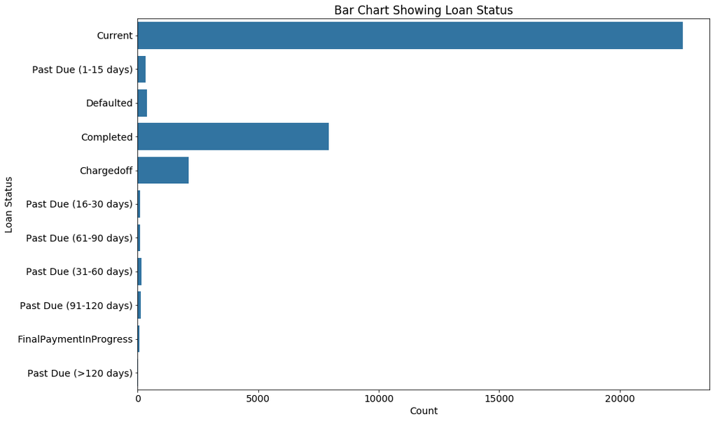

## (Visualization 2)

> Distribution of LoanStatus and Homeownership - Home owners are more likely to take loans and complete their loan payments.

```
Text(0.5,1,'Clustered Bar Chart Showing Loan Status & Homeownership')
```

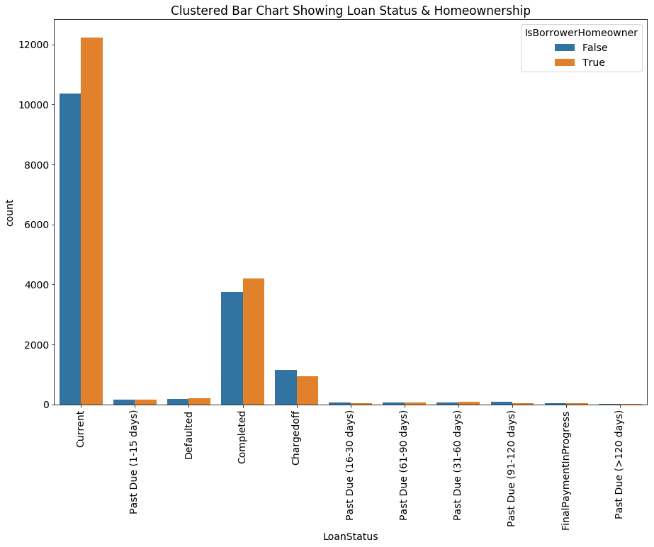

## (Visualization 3)

> Distribution of LoanStatus and ProsperScore - Listings with a Prosper Score of 4 are mostly under the 'current' loan status category and listings with a score of 8 have more completed payments. Listings with higher risk (higher ProsperScore) are more likely to have completed loan payments.

```
Text(5,1500,'1 being of lowest risk and 11 being highest risk ')
```

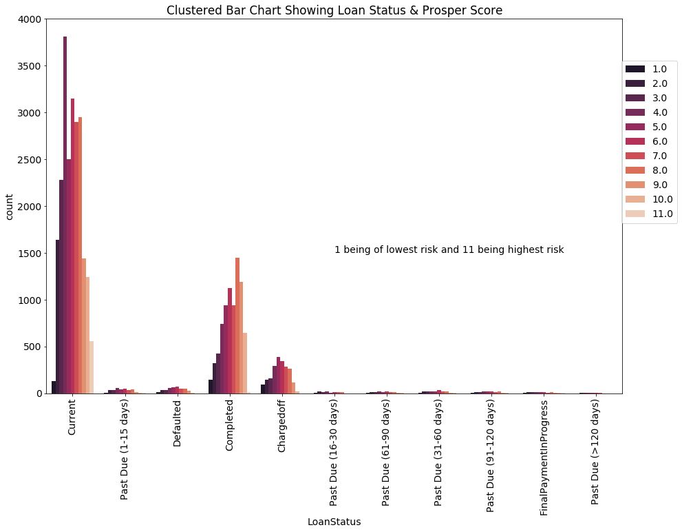

## (Visualization 4)

> Distribution of LoanStatus and Employment Status - People who are employed take more loans and are more likely to complete their loan payments.

[figure not shown]

## (Visualization 5)

> Distribution of LoanStatus and LoanOriginalAmount - Although listings under 10,000 with 'completed' as LoanStatus, it is not a clear indication that lower LoanOriginalAmount are more like to get paid off

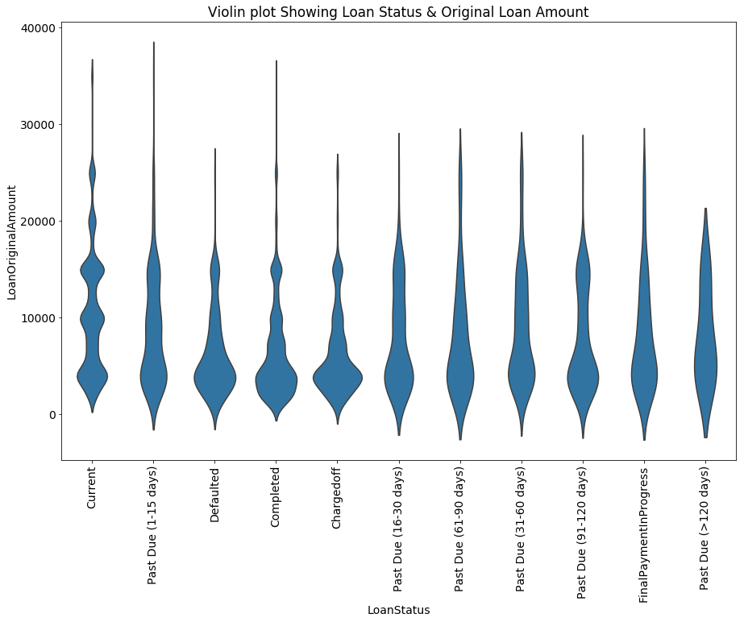